# BreastCancer_4Models

## 1. 环境配置与库导入

本cell导入项目所需的所有Python库，用于4种分类模型的对比实验。

```python
import os

os.environ["KMP_DUPLICATE_LIB_OK"] = "TRUE"

import matplotlib.pyplot as plt
plt.rcParams['font.sans-serif'] = ['SimHei']  # 用黑体显示中文
plt.rcParams['axes.unicode_minus'] = False    # 正常显示负号
import pandas as pd
import numpy as np
import matplotlib.pyplot as plt
import seaborn as sns
import time

from sklearn.datasets import load_breast_cancer
from sklearn.model_selection import train_test_split, cross_val_score
from sklearn.preprocessing import StandardScaler
from sklearn.linear_model import LogisticRegression
from sklearn.svm import SVC
from sklearn.ensemble import RandomForestClassifier
from sklearn.neighbors import KNeighborsClassifier
from sklearn.metrics import accuracy_score, precision_score, recall_score, f1_score, classification_report, confusion_matrix

print("="*60)
print("2.3 乳腺癌数据集 - 4种分类方法对比 - 崔靓颖")
print("="*60)
print("所有库导入成功！")
```

```
============================================================
2.3 乳腺癌数据集 - 4种分类方法对比 - 崔靓颖
============================================================
所有库导入成功！
```

## 2. 加载乳腺癌数据集

使用sklearn自带的威斯康辛州乳腺癌数据集。

```python
data = load_breast_cancer()
X = data.data
y = data.target

print(f"数据集大小: {len(X)} 个样本")
print(f"特征数量: {len(data.feature_names)}")
print(f"类别: {data.target_names} (0=恶性, 1=良性)")
print(f"标签分布: 恶性={sum(y==0)}, 良性={sum(y==1)}")
```

```
数据集大小: 569 个样本
特征数量: 30
类别: ['malignant' 'benign'] (0=恶性, 1=良性)
标签分布: 恶性=212, 良性=357
```

## 3. 数据划分和标准化

- 划分训练集（80%）和测试集（20%）
- 使用StandardScaler进行标准化

```python
X_train, X_test, y_train, y_test = train_test_split(
    X, y, test_size=0.2, random_state=42, stratify=y
)

scaler = StandardScaler()
X_train_scaled = scaler.fit_transform(X_train)
X_test_scaled = scaler.transform(X_test)

print(f"训练集: {X_train.shape[0]} 样本")
print(f"测试集: {X_test.shape[0]} 样本")
print("标准化完成")
```

```
训练集: 455 样本
测试集: 114 样本
标准化完成
```

## 4. 定义4种分类模型

本实验对比以下4种分类方法：

1. Logistic Regression（逻辑回归）- 线性模型
2. SVM（支持向量机）- 核方法
3. Random Forest（随机森林）- 集成学习
4. KNN（K近邻）- 基于距离的分类

```python
models = {
    'Logistic Regression': LogisticRegression(random_state=42, max_iter=1000),
    'SVM (RBF)': SVC(kernel='rbf', random_state=42),
    'Random Forest': RandomForestClassifier(n_estimators=100, random_state=42),
    'KNN (k=5)': KNeighborsClassifier(n_neighbors=5)
}

print("4种模型定义完成")
```

```
4种模型定义完成
```

## 5. 训练并评估4种模型

训练所有模型并记录准确率、精确率、召回率、F1分数和训练时间。

```python
results = []
all_predictions = {}

print("\n开始训练4种模型...")
print("-"*60)

for name, model in models.items():
    start_time = time.time()

    model.fit(X_train_scaled, y_train)
    y_pred = model.predict(X_test_scaled)
    all_predictions[name] = y_pred

    train_time = time.time() - start_time

    acc = accuracy_score(y_test, y_pred)
    prec = precision_score(y_test, y_pred)
    rec = recall_score(y_test, y_pred)
    f1 = f1_score(y_test, y_pred)

    results.append({
        '模型': name,
        'Accuracy': acc,
        'Precision': prec,
        'Recall': rec,
        'F1-score': f1,
        '训练时间(秒)': train_time
    })

    print(f"\n【{name}】")
    print(f"  准确率: {acc:.4f}")
    print(f"  精确率: {prec:.4f}")
    print(f"  召回率: {rec:.4f}")
    print(f"  F1分数: {f1:.4f}")
    print(f"  训练时间: {train_time:.4f} 秒")

print("-"*60)
print("所有模型训练完成！")
```

```
开始训练4种模型...
------------------------------------------------------------

【Logistic Regression】
  准确率: 0.9825
  精确率: 0.9861
  召回率: 0.9861
  F1分数: 0.9861
  训练时间: 0.0074 秒

【SVM (RBF)】
  准确率: 0.9825
  精确率: 0.9861
  召回率: 0.9861
  F1分数: 0.9861
  训练时间: 0.0142 秒

【Random Forest】
  准确率: 0.9561
  精确率: 0.9589
  召回率: 0.9722
  F1分数: 0.9655
  训练时间: 0.2477 秒

【KNN (k=5)】
  准确率: 0.9561
  精确率: 0.9589
  召回率: 0.9722
  F1分数: 0.9655
  训练时间: 0.0048 秒
------------------------------------------------------------
所有模型训练完成！
```

## 6. 结果汇总表格

将4种模型的评估指标汇总成表格。

```python
results_df = pd.DataFrame(results)
results_df = results_df.sort_values('Accuracy', ascending=False)

print("\n" + "="*60)
print("4种模型性能对比汇总表 ")
print("="*60)
print(results_df.to_string(index=False))
print("="*60)

results_df.to_csv('breast_cancer_4models_results.csv', index=False)
print("\n结果已保存到 breast_cancer_4models_results.csv")
```

```
============================================================
4种模型性能对比汇总表
============================================================
                 模型  Accuracy  Precision   Recall  F1-score  训练时间(秒)
Logistic Regression  0.982456   0.986111 0.986111  0.986111 0.007366
          SVM (RBF)  0.982456   0.986111 0.986111  0.986111 0.014191
      Random Forest  0.956140   0.958904 0.972222  0.965517 0.247738
          KNN (k=5)  0.956140   0.958904 0.972222  0.965517 0.004833
============================================================

结果已保存到 breast_cancer_4models_results.csv
```

## 7. 可视化对比

通过柱状图对比4种模型的性能指标和训练时间。

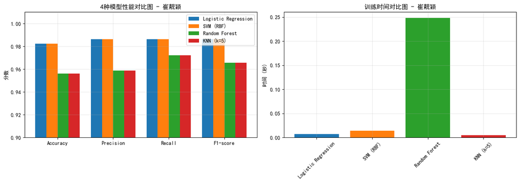

```python
fig, axes = plt.subplots(1, 2, figsize=(14, 5))

metrics = ['Accuracy', 'Precision', 'Recall', 'F1-score']
x = np.arange(len(metrics))
width = 0.2
colors = ['#1f77b4', '#ff7f0e', '#2ca02c', '#d62728']

for i, (idx, row) in enumerate(results_df.iterrows()):
    values = [row[m] for m in metrics]
    axes[0].bar(x + i*width, values, width, label=row['模型'], color=colors[i])

axes[0].set_ylabel('分数')
axes[0].set_title('4种模型性能对比图 - 崔靓颖')
axes[0].set_xticks(x + width * 1.5)
axes[0].set_xticklabels(metrics)
axes[0].legend()
axes[0].set_ylim(0.9, 1.01)
axes[0].grid(True, alpha=0.3)

axes[1].bar(results_df['模型'], results_df['训练时间(秒)'], color=colors)
axes[1].set_ylabel('时间 (秒)')
axes[1].set_title('训练时间对比图 - 崔靓颖')

# 先设置刻度位置，再旋转标签
axes[1].set_xticks(np.arange(len(results_df['模型'])))
axes[1].set_xticklabels(results_df['模型'])
axes[1].tick_params(axis='x', rotation=45, labelsize=10)

axes[1].grid(True, alpha=0.3)

plt.tight_layout()
plt.savefig('breast_cancer_4models_comparison.png', dpi=150)
plt.show()
```

## 8. 混淆矩阵对比

绘制4种模型的混淆矩阵，直观对比分类效果。

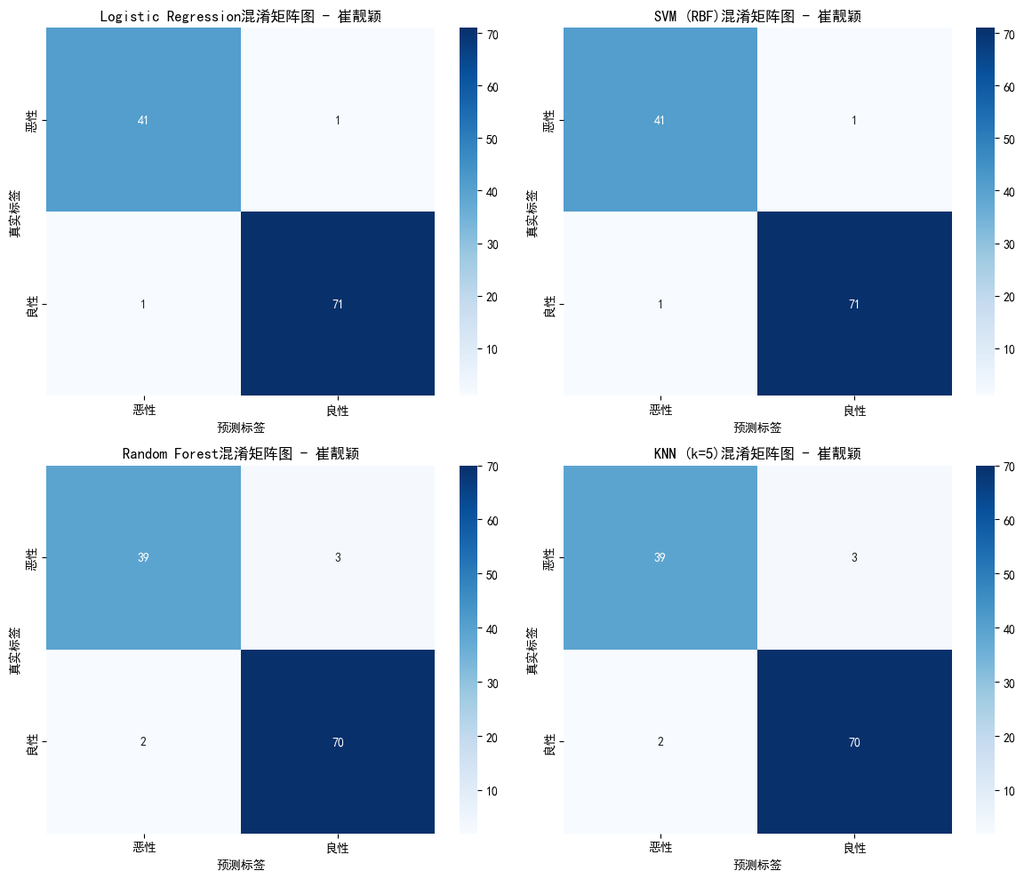

```python
fig, axes = plt.subplots(2, 2, figsize=(12, 10))
axes = axes.flatten()

for idx, (name, model) in enumerate(models.items()):
    y_pred = all_predictions[name]
    cm = confusion_matrix(y_test, y_pred)

    sns.heatmap(cm, annot=True, fmt='d', cmap='Blues',
                xticklabels=['恶性', '良性'],
                yticklabels=['恶性', '良性'],
                ax=axes[idx])
    axes[idx].set_title(f'{name}混淆矩阵图 - 崔靓颖')
    axes[idx].set_xlabel('预测标签')
    axes[idx].set_ylabel('真实标签')

plt.tight_layout()
plt.savefig('breast_cancer_4models_confusion.png', dpi=150)
plt.show()
```

## 9. 详细分类报告

输出每个模型的详细分类报告，包括各类别的精确率、召回率和F1分数。

```python
print("\n" + "="*60)
print("各模型详细分类报告")
print("="*60)

for name, y_pred in all_predictions.items():
    print(f"\n【{name}】 - 崔靓颖")
    print(classification_report(y_test, y_pred, target_names=['恶性', '良性']))
```

```
============================================================
各模型详细分类报告
============================================================

【Logistic Regression】 - 崔靓颖
              precision    recall  f1-score   support

          恶性       0.98      0.98      0.98        42
          良性       0.99      0.99      0.99        72

    accuracy                           0.98       114
   macro avg       0.98      0.98      0.98       114
weighted avg       0.98      0.98      0.98       114


【SVM (RBF)】 - 崔靓颖
              precision    recall  f1-score   support

          恶性       0.98      0.98      0.98        42
          良性       0.99      0.99      0.99        72

    accuracy                           0.98       114
   macro avg       0.98      0.98      0.98       114
weighted avg       0.98      0.98      0.98       114


【Random Forest】 - 崔靓颖
              precision    recall  f1-score   support

          恶性       0.95      0.93      0.94        42
          良性       0.96      0.97      0.97        72

    accuracy                           0.96       114
   macro avg       0.96      0.95      0.95       114
weighted avg       0.96      0.96      0.96       114


【KNN (k=5)】 - 崔靓颖
              precision    recall  f1-score   support

          恶性       0.95      0.93      0.94        42
          良性       0.96      0.97      0.97        72

    accuracy                           0.96       114
   macro avg       0.96      0.95      0.95       114
weighted avg       0.96      0.96      0.96       114
```

## 10. 5折交叉验证

使用5折交叉验证评估模型的稳定性，计算准确率的均值和标准差。

```
============================================================
5折交叉验证结果（均值±标准差）
============================================================

Logistic Regression:
  准确率: 0.9802 ± 0.0128

SVM (RBF):
  准确率: 0.9714 ± 0.0179

Random Forest:
  准确率: 0.9538 ± 0.0235

KNN (k=5):
  准确率: 0.9670 ± 0.0209
```

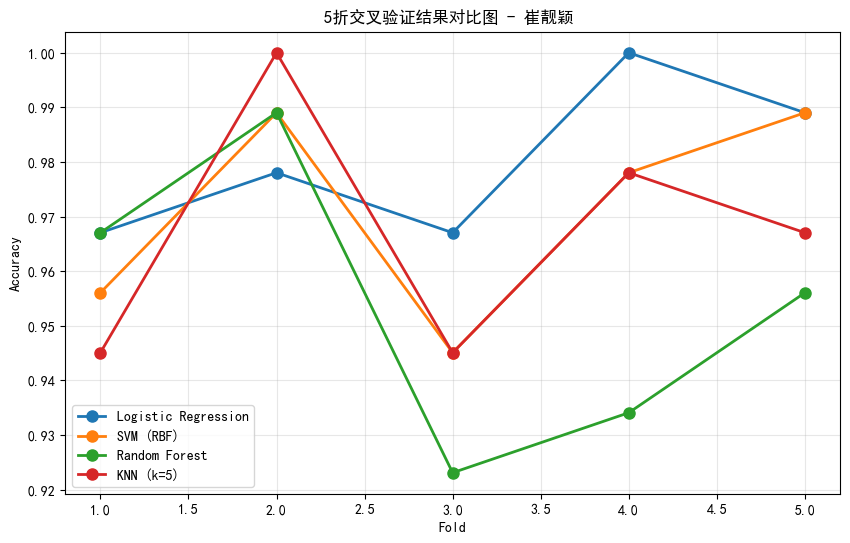

```python
print("\n" + "="*60)
print("5折交叉验证结果（均值±标准差）")
print("="*60)

cv_results = {}
plt.figure(figsize=(10, 6))

for name, model in models.items():
    cv_scores = cross_val_score(model, X_train_scaled, y_train, cv=5, scoring='accuracy')
    cv_results[name] = cv_scores
    print(f"\n{name}:")
    print(f"  准确率: {cv_scores.mean():.4f} ± {cv_scores.std():.4f}")
    plt.plot(range(1, 6), cv_scores, 'o-', label=name, linewidth=2, markersize=8)

plt.xlabel('Fold')
plt.ylabel('Accuracy')
plt.title('5折交叉验证结果对比图 - 崔靓颖 ')
plt.legend()
plt.grid(True, alpha=0.3)
plt.savefig('breast_cancer_cross_validation.png', dpi=150)
plt.show()
```

## 11. 实验结论与总结

### 11.1 实验结果总结

本实验使用4种分类方法对威斯康辛州乳腺癌数据集进行分类，主要结论如下：

[output not shown]

### 11.3 结论

乳腺癌数据集的特征与标签之间存在较强的线性关系，因此逻辑回归这类线性模型就能取得很好的效果。对于实际医疗诊断应用，建议优先使用逻辑回归或SVM，它们不仅准确率高，而且训练速度快。

**报告完成日期：** 2026年6月 **作者：** 崔靓颖